Back »

Model Analysis and Evaluation

# Ordinal Regression

The run function loads training, development, and test data, trains an OrdinalClassifier using binary bag-of-words featurization, and evaluates its accuracy. It then calculates and prints the 95% confidence intervals for the test accuracy.

```python
def confidence_intervals(accuracy, n, significance_level):
    critical_value=(1-significance_level)/2
    z_alpha=-1*norm.ppf(critical_value)
    se=math.sqrt((accuracy*(1-accuracy))/n)
    return accuracy-(se*z_alpha), accuracy+(se*z_alpha)
```

```python
def run(trainingFile, devFile, testFile, ordinal_values):


    trainX, trainY, orig_trainY=load_ordinal_data(trainingFile, ordinal_values)
    devX, devY, orig_devY=load_ordinal_data(devFile, ordinal_values)
    testX, testY, orig_testY=load_ordinal_data(testFile, ordinal_values)

    simple_classifier = OrdinalClassifier(ordinal_values, binary_bow_featurize, trainX, trainY, devX, devY, testX, testY, orig_trainY, orig_devY, orig_testY)
    simple_classifier.train()
    accuracy=simple_classifier.test()

    lower, upper=confidence_intervals(accuracy, len(testY[0]), .95)
    print("Test accuracy for best dev model: %.3f, 95%% CIs: [%.3f %.3f]\n" % (accuracy, lower, upper))
```

```python
trainingFile = "splits/train.txt"
devFile = "splits/dev.txt"
testFile = "splits/test.txt"

# ordinal values must be in order *as strings* from smallest to largest, e.g.:
# ordinal_values=["G", "PG", "PG-13", "R"]

ordinal_values=["NP", "DP", "MP"]

run(trainingFile, devFile, testFile, ordinal_values)
```

```
Test accuracy for best dev model: 0.644, 95% CIs: [0.550 0.737]
```

# Logistic Regression

The run function loads training, development, and test data, trains an LogisticClassifier using binary bag-of-words featurization, and evaluates its accuracy. It then calculates and prints the 95% confidence intervals for the test accuracy.

```python
def confidence_intervals(accuracy, n, significance_level):
    critical_value=(1-significance_level)/2
    z_alpha=-1*norm.ppf(critical_value)
    se=math.sqrt((accuracy*(1-accuracy))/n)
    return accuracy-(se*z_alpha), accuracy+(se*z_alpha)
```

```python
def run(trainingFile, devFile, testFile):
        trainX, trainY=load_data(trainingFile)
        devX, devY=load_data(devFile)
        testX, testY=load_data(testFile)

        simple_classifier = Classifier(binary_bow_featurize, trainX, trainY, devX, devY, testX, testY)
        simple_classifier.train()
        accuracy=simple_classifier.test()

        lower, upper=confidence_intervals(accuracy, len(testY), .95)
        print("Test accuracy for best dev model: %.3f, 95%% CIs: [%.3f %.3f]\n" % (accuracy, lower, upper))

        simple_classifier.printWeights()
```

```python
trainingFile = "splits/train.txt"
    devFile = "splits/dev.txt"
    testFile = "splits/test.txt"

    run(trainingFile, devFile, testFile)
```

```
Test accuracy for best dev model: 0.624, 95% CIs: [0.529 0.718]

    DP	0.507	non-exclus
    DP	0.434	exceed
    DP	0.378	permit
    DP	0.337	sole
    DP	0.308	non-transfer
    DP	0.238	except
    DP	0.228	liabil
    DP	0.224	worldwid
    DP	0.221	royalti
    DP	0.220	licens

    MP	0.588	exclus
    MP	0.284	must
    MP	0.280	term
    MP	0.220	not
    MP	0.205	ani
    MP	0.204	take
    MP	0.196	exclus_right
    MP	0.189	pay
    MP	0.183	expir
    MP	0.173	case

    NP	0.324	negoti
    NP	0.289	liabl
    NP	0.284	first
    NP	0.267	may
    NP	0.262	special
    NP	0.231	have
    NP	0.212	commerci
    NP	0.191	set
    NP	0.190	advis
    NP	0.161	amend
```

# Analysis

## Analysis 1: Model Selection

In terms of model selection, we chose three classifiers to compare: BERT, logistic regression, and ordinal regression. When we used BERT with an embedding size of 768, we received “CUDA out of memory” error which can be attributed to having a big batch size and low GPU memory of the remote machine. Through trial and error, we have reached the conclusion that there was a tradeoff between computation time for memory usage especially when we had a bigger BOW dataset so we decided to rule this classifier out.

Next, we have tried using logistic regression which has resulted in an accuracy score of 62.4% and 95% confidence interval of [0.529, 0.718]. Then we opted in for the ordinal regression classifier as our labels [MP DP NP] are multicategorical as well as in order of how binding a given legal clause is. The accuracy score for ordinal regression was 64.4% with a 95% confidence interval of [0.550, 0.737]. Overall, we chose the ordinal regression as it incurred a higher accuracy score and had a narrower confidence interval making the model more reliable. Granted, the classifier’s ability in predicting the true labels didn’t differ significantly which we assume is due to the unclear boundary between our ordinal labels as ordinal regression assumes natural ordering between labels. We believe there are numerous cases where we fail to distinguish MP and DP (which will be discussed more in the confusion matrix) which renders our model insufficient to choose over our simple regression model. Minor point to note is that having a small dataset size also makes it practically harder to distinguish between the 3 labels.

## Analysis 2: Confusion Matrix

```python
from sklearn.metrics import confusion_matrix, ConfusionMatrixDisplay
trainX, trainY, orig_trainY=load_ordinal_data(trainingFile, ordinal_values)
devX, devY, orig_devY=load_ordinal_data(devFile, ordinal_values)
testX, testY, orig_testY=load_ordinal_data(testFile, ordinal_values)

simple_classifier = OrdinalClassifier(ordinal_values, binary_bow_featurize, trainX, trainY, devX, devY, testX, testY, orig_trainY, orig_devY, orig_testY)
simple_classifier.train()
preds, org_labels=simple_classifier.predict()
```

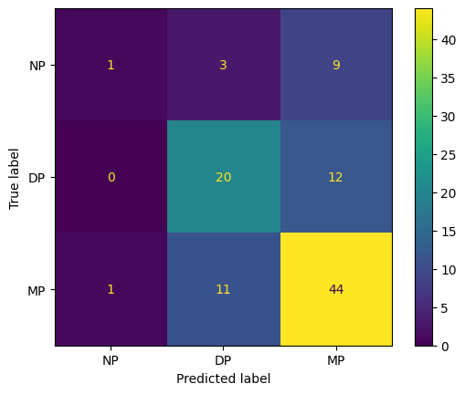

```python
from sklearn.metrics import confusion_matrix, ConfusionMatrixDisplay
cm = confusion_matrix(org_labels, preds, labels=[0, 1, 2])
disp = ConfusionMatrixDisplay(confusion_matrix=cm, display_labels=ordinal_values)
disp.plot();
```

Based on the confusion matrix above, we could analyze which labels the model often mistakens which other labels. Looking at the MP row first, it can be seen that the model does get most of the data points with a true label of MP correctly with 44/56 being correctly classified. However, 11/56 with true label as MP were classified as DP and 1/56 was classified as NP. This suggests that model may have some difficulty separating between the DP and MP classes.

For the data points that have true label as NP, it can be seen most of these were actually classified as MP which is interesting considering these two categories are not adjacent in terms of the ordering of the ordinal values. This may be due to the fact that some data points have words or phrases that indicate both NP and MP which may make the model struggle classifying these correctly. This may also be due to the fact there may just be too few data points in the NP category so the model does not have enough data to recognize any patterns that might be in the NP category. This also might suggest that this category may need to be more defined in the guidelines as the model was only able to correctly classify 1/13.

## Analysis 3: Feature Analysis

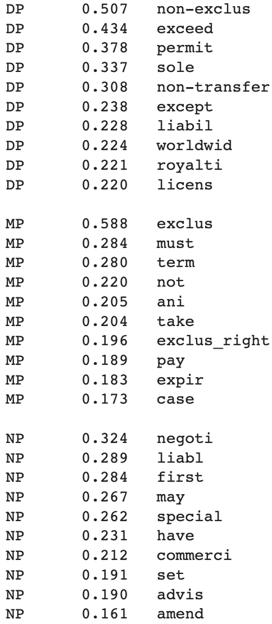

The feature weights above were gathered from running the logistic regression notebook with the same features we have defined in this ordinal regression notebook. Words from the training were stemmed which explains why the features above are stemmed as well. Looking at the MP category first, it can be seen that the three most important features for distinguishing this category are ‘exclusive’, ‘must’, and ‘term’. Both ‘exclusive’ and ‘must’ align well with our guidelines since these are key words and phrases that we have defined in the guidelines to indicate a data point is more likely to be MP. However, the word ‘term’ was not really present in our guidelines which may indicate that the model has identified a pattern in predicting this class that we may not have accounted for in the guidelines itself.

For the DP category, the three most important features were ‘non-exclusive’, ‘exceed’ and ‘permit’. For the ‘non-exclusive’ feature, this aligns well with our guidelines since this term is likely tied to the mention of a license which we have defined in the guidelines that it should be DP. Also the ‘exceed’ feature also aligns well with our guidelines since it likely indicates the presence of data point mentioning a liability cap which we have defined as the DP category in the guidelines.

For the NP category, the three most important features were ‘negotiate’, ‘liability’, and ‘first’. The ‘negotiate’ features aligns well with our guidelines since it most likely indicates a potential room to change an agreement which is not very binding and we have defined this as the NP category. Also the ‘liability’ feature also aligns with our guidelines since it most likely indicates the lack of liability a party might have which we have defined as NP. On the other hand, the feature ‘first’ does not really align with our guidelines and it may be due to the model potentially fitting to noise in the NP category specifically since there are so few NP data points in training compared to the other categories.

## Analysis 4: Class Balance

```python
import pandas as pd
train = pd.read_csv("splits/train.txt", sep='\t', header=None)
train[2].value_counts()
```

```
MP    146
DP    110
NP     48
Name: 2, dtype: int64
```

```python
test = pd.read_csv("splits/test.txt", sep='\t', header=None)
test[2].value_counts()
```

```
MP    56
DP    32
NP    13
Name: 2, dtype: int64
```

```python
from sklearn.metrics import f1_score
f1_score(org_labels, preds, average=None)
```

```
array([0.13333333, 0.60606061, 0.72727273])
```

## Analysis 5: Implications

Overall based on our analysis, it seems as though the model particularly has the most trouble distinguishing between the DP and MP categories. This may indicate that our guidelines may need to be more well defined. If we were to change our guidelines, we may perhaps look at going through the training set again to define more clear rules to distinguish the two categories. Perhaps there may be more ambiguity than we had originally thought when creating the guidelines and annotating the data. Maybe making more clear rules in the guidelines to separate classes may lead to better overall model performance.

Putting all our results and analysis together, we believe law firms and legal departments could use our model to automate the review process of legal contracts to better determine which contracts to focus on. This could also be used for risk management as the more legally binding a contract is, the more risk associated with making decisions. As a whole, we believe our model could act as a general guideline for creating a metric to determine the legal consequences/impact of a contract.